# Принципы и паттерны проектирования

Кирилл Корняков  
Апрель 2013

# Содержание

1. Ключевые понятия и основные рекомендации
2. SOLID принципы
3. Некоторые паттерны и архитектурные стили
4. Заключение

# Закон Конвея

*Организации, проектирующие системы, неизбежно производят системы, являющиеся копиями их коммуникационных структур.* 1968 год

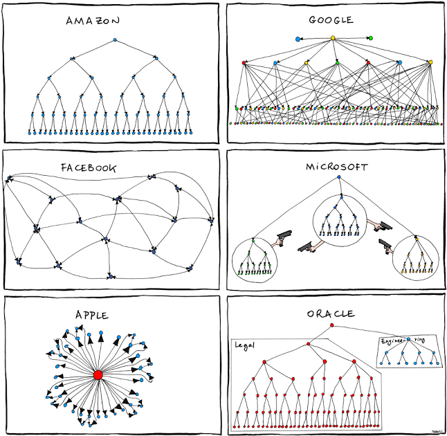

# Дизайн

*Дизайн программной системы документирован главным образом ее исходным кодом.*

Роберт Мартин, Джек Ривз

# Плохой дизайн

- Как бы вы описали плохой дизайн?
- Плохой дизайн, это когда...

# Плохой дизайн

[figure not shown]

# Болезни дизайна

Р. Мартин, М. Мартин *"Принципы, паттерны и методики гибкой разработки на языке C#"*

1. **Жесткость** - сложно менять
2. **Хрупкость** - легко сломать
3. **Неподвижность** - сложно переиспользовать
4. **Вязкость** - когда проще делать хаки, чем поддерживать дизайн
5. **Ненужная сложность** - надуманный дизайн, программирование "на будущее"
6. **Ненужные повторения** - Copy-and-Paste
7. **Непрозрачность** - сложно разобраться и понять

# Ориентиры

1. Простота
   - Agile: Simplicity - the art of maximizing the amount of work not done - is essential.
   - XP: "Do The Simplest Thing That Could Possibly Work"
   - XP: "You aren't gonna need it" (YAGNI)
   - Стремитесь к простоте, "правило первой пули"
2. Единый стиль
   - Следуйте общепринятым правилам
3. Ортогональность
   - Минимизируйте взаимовлияние различных частей системы
4. Итеративность и инкрементальность
   - Непрерывно улучшайте дизайн (рефакторинг)
   - XP: Evolutionary Architecture

# Киты ООП

1. Инкупсуляция
2. Наследование
3. Полиморфизм
4. Абстрация

Саттер Г., Александреску А. *"Стандарты программирования на C++"*

# Инкапсуляция

- *"Делайте данные-члены закрытыми"*
- *"Не допускайте вмешательства во внутренние дела"*
- *"Разумно пользуйтесь идиомой Pimpl"*

Классами становится просто пользоваться, сложно сломать, легко поддерживать.

# Наследование

- *"Предпочитайте композицию наследованию"*
- *"Предпочитайте предоставление абстрактных интерфейсов"*
- "Наследовать надо не для повторного использования,  
  а чтобы быть повторно использованным"
- *"Избегайте наследования от классов, которые не спроектированы для этой цели"*

Старайтесь избегать, если вы не уверены на 100%.

# Полиморфизм

- *"Разумно сочетайте статический и динамический полиморфизм"*
- *"Избегайте явного выбора типов - используйте полиморфизм"*
- *"Виртуальные функции стоит делать неоткрытыми, а открытые - невиртуальными"*

Позволяет локализовать изменения, писать меньше кода и делать код "расширяемым".

# Ключевые понятия

1. Интерфейсы и абстракции
   - GoF *"Program to an 'interface', not an 'implementation'"*
   - Паттерн Фасад
2. Зависимости
   - Минимизируйте внутренние и внешние зависимости
3. Ответственности
   - The UNIX Philosophy: Make each program do one thing well
   - "Один объект - одна задача"
   - "Предпочитайте минимальные классы монолитным"

# SOLID

- SRP - Single Responsibility Principle
- OCP - Open-Closed Principle
- LSP - Liskow Substitution Principle
- ISP - Interface Segregation Principle
- DIP - Dependency Inversion Principle

# Несколько полезных паттернов

- Factory method
- Facade
- Паттерны GUI
  - MVC, MVP (Passive View), MVVM

# Factory Method

```
  public class ImageReaderFactory {
    public static ImageReader createImageReader(ImageType type) {
        ImageReader reader = null;

        if( type.isGIF() ) {
          reader = new GifReader();
        }
        else if( type.isJPEG() ) {
          reader = new JpegReader();
        }
        else {
          throw new IllegalArgumentException( "Unknown image type." );
        }

        return reader;
    }
  }
```

```
class FaceRecognizer;
Ptr<FaceRecognizer> createEigenFaceRecognizer(int num_components=0, double threshold=DBL_MAX);
Ptr<FaceRecognizer> createFisherFaceRecognizer(int num_components=0, double threshold=DBL_MAX);
Ptr<FaceRecognizer> createLBPHFaceRecognizer(int radius=1, int neighbors=8, int grid_x=8, ...);
```

# Facade

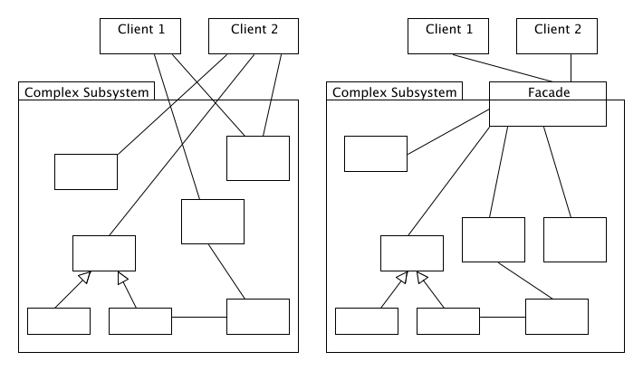

# MVP - Passive View

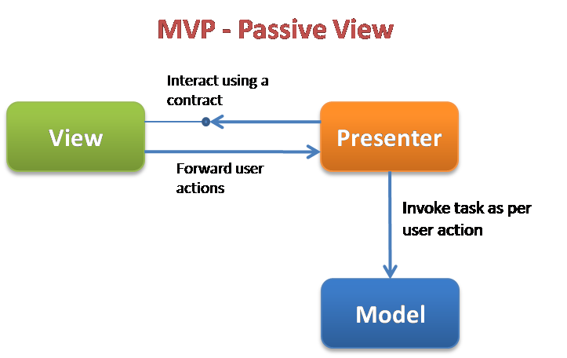

# Architectural Styles

- Client / Server
- Component-Based
- Domain Driven Design
- Layered
- Message Bus
- N-Tier / 3-Tier
- Object-Oriented
- Service-Oriented

[*"Microsoft Application Architecture Guide"*](http://msdn.microsoft.com/en-us/library/ff650706.aspx), 2nd Edition

# DDD Layered Architecture

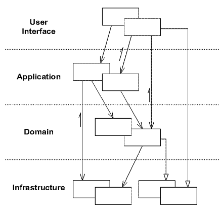

# DDD N-Layered Architecture

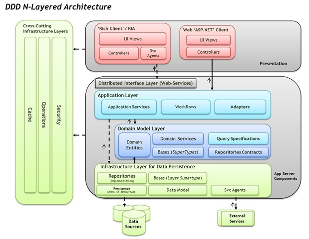

# DDD N-Layered Architecture

[figure not shown]

# Onion and Hexagonal Architecture

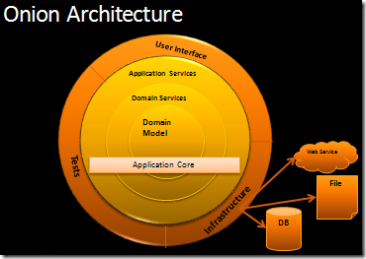

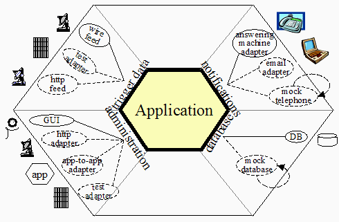

# The Zen of Python

```
Beautiful is better than ugly
Explicit is better than implicit
Simple is better than complex
Complex is better than complicated
Flat is better than nested
Sparse is better than dense
Readability counts
Special cases aren't special enough to break the rules
Although practicality beats purity
Errors should never pass silently
Unless explicitly silenced
In the face of ambiguity, refuse the temptation to guess
There should be one -- and preferably only one -- obvious way to do it
Although that way may not be obvious at first unless you're Dutch
Now is better than never
Although never is often better than *right* now
If the implementation is hard to explain, it's a bad idea
If the implementation is easy to explain, it may be a good idea
Namespaces are one honking great idea -- let's do more of those!
```

# Ссылки

1. Robert Martin *"[SOLID](http://www.objectmentor.com/resources/articles/Principles_and_Patterns.pdf) principles"*
2. Р. Мартин, М. Мартин *"Принципы, паттерны и методики гибкой разработки на языке C#"*
3. Саттер Г., Александреску А. *"Стандарты программирования на C++"*
4. [*"Microsoft Application Architecture Guide"*](http://msdn.microsoft.com/en-us/library/ff650706.aspx), 2nd Edition
5. Krzysztof Cwalina, Brad Abrams *"Framework Design Guidelines: Conventions, Idioms, and Patterns for Reusable .NET Libraries*", 2nd Edition
6. GoF *"Design Patterns: Elements of Reusable Object-Oriented Software"*
7. Martin Fowler [*"Catalog of Patterns of Enterprise Application Architecture"*](http://martinfowler.com/eaaCatalog/)
8. **GitHub**

# Спасибо за внимание!

- Вопросы?